# feature_selection_RF

En este notebook se va a cargar el dataset de expresión génica GSE137356 y se va a hacer una selección de atributos de mismo mediante Random Forest

El primer paso es cargar el dataset de expresión génica en ex_ge_ds además de dos datasets auxiliares que servirán para hacer la traducción entre el nombre de cada sonda y su gen en sonda_gen y gen_sonda respectivamente

```python
import pandas as pd

ex_ge_ds = pd.read_csv("GSE137356_series_matrix.csv", sep=';', index_col="NAME")

ex_ge_ds.head(10)
```

| NAME | GSM4077013 | GSM4077014 | GSM4077015 | GSM4077016 | GSM4077017 | GSM4077018 | GSM4077019 | GSM4077020 | GSM4077021 | GSM4077022 | ... | GSM4077397 | GSM4077398 | GSM4077399 | GSM4077400 | GSM4077401 | GSM4077402 | GSM4077403 | GSM4077404 | GSM4077405 | GSM4077406 |
| --- | --- | --- | --- | --- | --- | --- | --- | --- | --- | --- | --- | --- | --- | --- | --- | --- | --- | --- | --- | --- | --- |
| 200000_s_at | 42.096 | 46.237 | 50.945 | 62.267 | 61.879 | 65.202 | 62.309 | 56.592 | 48.074 | 61.654 | ... | 94.725 | 9.391 | 92.898 | 97.413 | 94.815 | 94.914 | 93.992 | 94.128 | 94.117 | 96.759 |
| 200001_at | 68.265 | 69.943 | 92.234 | 88.768 | 83.916 | 96.033 | 92.726 | 87.298 | 82.411 | 92.091 | ... | 114.331 | 113.807 | 112.618 | 111.073 | 108.708 | 112.686 | 112.425 | 11.263 | 111.921 | 114.673 |
| 200002_at | 78.772 | 82.004 | 87.915 | 97.438 | 98.469 | 87.529 | 115.998 | 78.597 | 91.017 | 92.073 | ... | 126.494 | 124.909 | 125.042 | 125.042 | 12.391 | 125.042 | 124.298 | 124.446 | 125.042 | 125.662 |
| 200003_s_at | 80.215 | 66.756 | 8.302 | 103.857 | 89.643 | 92.291 | 96.949 | 72.212 | 84.975 | 9.198 | ... | 124.373 | 123.254 | 122.392 | 123.527 | 120.926 | 122.226 | 120.863 | 121.144 | 122.097 | 124.326 |
| 200004_at | 36.698 | 56.573 | 56.583 | 58.173 | 53.696 | 66.452 | 62.836 | 44.926 | 36.548 | 62.653 | ... | 95.204 | 97.145 | 96.035 | 96.106 | 94.707 | 96.714 | 97.963 | 96.936 | 96.103 | 95.961 |
| 200005_at | 46.732 | 49.135 | 60.976 | 58.885 | 67.895 | 55.167 | 61.999 | 55.892 | 53.984 | 60.725 | ... | 95.752 | 96.731 | 95.086 | 9.429 | 9.054 | 9.544 | 95.086 | 94.928 | 93.535 | 94.947 |
| 200006_at | 48.487 | 51.956 | 61.711 | 66.183 | 68.901 | 5.833 | 69.996 | 67.646 | 63.084 | 69.263 | ... | 109.562 | 109.304 | 110.425 | 110.311 | 108.545 | 110.169 | 109.915 | 109.326 | 109.533 | 10.890 |
| 200007_at | 56.365 | 7.109 | 87.768 | 82.745 | 67.436 | 71.909 | 76.532 | 70.901 | 69.523 | 73.864 | ... | 115.513 | 115.676 | 115.187 | 113.996 | 112.329 | 115.188 | 114.161 | 115.152 | 114.074 | 115.167 |
| 200008_s_at | 65.368 | 66.569 | 93.627 | 95.496 | 83.766 | 81.698 | 80.119 | 71.941 | 84.487 | 79.901 | ... | 10.860 | 108.396 | 108.072 | 105.402 | 104.143 | 107.636 | 107.088 | 106.587 | 106.352 | 108.618 |
| 200009_at | 61.583 | 76.359 | 91.088 | 88.715 | 85.402 | 86.981 | 81.706 | 78.455 | 79.568 | 80.498 | ... | 109.168 | 110.142 | 109.192 | 108.177 | 106.722 | 109.081 | 109.892 | 110.052 | 108.953 | 109.192 |

10 rows × 394 columns

```python
sonda_gen = pd.read_csv("GPL23985-23107_probeid_gen.csv", sep=';', index_col="ID")
sonda_gen.head(10)
```

| ID | Gene.Symbol |
| --- | --- |
| ADXEC.16333.C1_s_at | 36951 |
| ADXEC.1735.C1_at | 36951 |
| ADXECAD.19560_at | 36951 |
| ADXECAD.3848_at | 36951 |
| ADXECEMUTR.4562_at | 36951 |
| ADXECEMUTR.7229_at | 36951 |
| ADXECEMUTR.7229_x_at | 36951 |
| ADXECEMUTR.7230_at | 36951 |
| ADXECRS.38483_s_at | 36951 |
| ADXEC.26151.C1_at | 37104 |

```python
gen_sonda = pd.read_csv("GPL23985-23107_probeid_gen.csv", sep=';', index_col="Gene.Symbol")
gen_sonda.head(10)
```

| Gene.Symbol | ID |
| --- | --- |
| 36951 | ADXEC.16333.C1_s_at |
| 36951 | ADXEC.1735.C1_at |
| 36951 | ADXECAD.19560_at |
| 36951 | ADXECAD.3848_at |
| 36951 | ADXECEMUTR.4562_at |
| 36951 | ADXECEMUTR.7229_at |
| 36951 | ADXECEMUTR.7229_x_at |
| 36951 | ADXECEMUTR.7230_at |
| 36951 | ADXECRS.38483_s_at |
| 37104 | ADXEC.26151.C1_at |

Ahora vamos a incluir en el dataset ex_ge_ds el nombre del gen al que corresponde cada sonda, ayudándonos del dataset sonda_gen, para a continuación hacer un filtrado de aquellas sondas en las que hemos encontrado su gen.

```python
genes = []

#  buscamos el Gene_symbol de cada fila de ex_ge_ds
for index, row in ex_ge_ds.iterrows():
    genes.append(sonda_gen.loc[index]["Gene.Symbol"])

#  creamos una nueva columna Gene.Symbol en ex_ge_ds
ex_ge_ds.insert(0, "GeneSymbol", genes, True)

#  ordenamos ex_ge_ds por el valor de Gene.Symbol
ex_ge_ds.sort_values('GeneSymbol', inplace=True, ascending=True)

#  nos quedamos las sondas para las que hemos encontrado su gen
ex_ge_ds_nona = ex_ge_ds[ex_ge_ds.GeneSymbol != "---"]

ex_ge_ds_nona.head(10)
```

| NAME | GeneSymbol | GSM4077013 | GSM4077014 | GSM4077015 | GSM4077016 | GSM4077017 | GSM4077018 | GSM4077019 | GSM4077020 | GSM4077021 | ... | GSM4077397 | GSM4077398 | GSM4077399 | GSM4077400 | GSM4077401 | GSM4077402 | GSM4077403 | GSM4077404 | GSM4077405 | GSM4077406 |
| --- | --- | --- | --- | --- | --- | --- | --- | --- | --- | --- | --- | --- | --- | --- | --- | --- | --- | --- | --- | --- | --- |
| ADXECRS.38499_at | 1060P11.3 /// KIR3DP1 | 32.188 | 26.405 | 24.039 | 22.393 | 28.256 | 21.434 | 26.212 | 25.657 | 2.306 | ... | 29.614 | 29.056 | 28.409 | 29.101 | 27.757 | 27.126 | 29.526 | 29.428 | 30.205 | 29.756 |
| ADXECEMUTR.7229_x_at | 36951 | 1.677 | 19.007 | 11.152 | 19.019 | 13.818 | 17.787 | 14.724 | 14.118 | 14.693 | ... | 22.068 | 22.926 | 23.338 | 22.578 | 22.495 | 23.278 | 21.844 | 21.759 | 23.461 | 23.285 |
| ADXEC.1735.C1_at | 36951 | 1.876 | 3.306 | 17.107 | 3.102 | 20.426 | 19.737 | 14.965 | 19.056 | 16.464 | ... | 34.612 | 3.874 | 29.721 | 29.422 | 39.545 | 38.518 | 33.147 | 36.142 | 2.971 | 3.610 |
| ADXECAD.3848_at | 36951 | 27.436 | 36.225 | 29.313 | 26.179 | 29.414 | 3.142 | 21.345 | 28.375 | 31.236 | ... | 25.672 | 29.054 | 28.096 | 28.674 | 26.552 | 23.547 | 27.617 | 26.491 | 30.928 | 28.452 |
| ADXECEMUTR.4562_at | 36951 | 72.484 | 5.672 | 47.997 | 6.445 | 37.795 | 44.755 | 48.074 | 37.777 | 51.243 | ... | 66.743 | 67.195 | 66.083 | 67.246 | 67.896 | 64.189 | 63.723 | 60.603 | 67.055 | 63.064 |
| ADXECAD.19560_at | 36951 | 79.766 | 85.371 | 80.803 | 80.484 | 83.938 | 75.874 | 7.119 | 76.981 | 92.275 | ... | 77.126 | 74.541 | 76.441 | 59.262 | 68.745 | 80.301 | 75.247 | 7.426 | 77.235 | 74.143 |
| ADXECRS.38483_s_at | 36951 | 44.176 | 53.372 | 53.527 | 65.013 | 33.244 | 50.613 | 45.283 | 43.327 | 63.786 | ... | 78.272 | 79.403 | 75.743 | 74.833 | 77.243 | 80.137 | 76.272 | 75.047 | 80.327 | 75.886 |
| ADXEC.16333.C1_s_at | 36951 | 1.731 | 25.997 | 33.678 | 29.541 | 3.700 | 33.164 | 23.312 | 31.995 | 45.134 | ... | 48.761 | 42.652 | 44.713 | 47.963 | 40.014 | 47.742 | 41.055 | 41.062 | 3.813 | 46.743 |
| ADXECEMUTR.7230_at | 36951 | 33.735 | 60.401 | 44.918 | 49.482 | 32.144 | 34.806 | 33.287 | 34.553 | 31.665 | ... | 38.725 | 36.135 | 38.767 | 3.691 | 37.394 | 3.744 | 36.442 | 39.748 | 39.016 | 37.669 |
| ADXECEMUTR.7229_at | 36951 | 14.522 | 18.878 | 13.198 | 13.297 | 15.308 | 12.668 | 12.047 | 12.045 | 16.953 | ... | 22.542 | 19.575 | 21.124 | 23.498 | 20.223 | 20.843 | 2.006 | 21.124 | 22.095 | 21.167 |

10 rows × 395 columns

Existen sondas pertenecientes a un mismo gen, en este caso lo que vamos a realizar es calcular los valores medios y quedarnos con una única sonda por gen.

```python
ex_ge_ds_nona_mean = ex_ge_ds_nona.groupby('GeneSymbol', as_index=False).mean()
ex_ge_ds_nona_mean.head(10)
```

|  | GeneSymbol | GSM4077013 | GSM4077014 | GSM4077015 | GSM4077016 | GSM4077017 | GSM4077018 | GSM4077019 | GSM4077020 | GSM4077021 | ... | GSM4077397 | GSM4077398 | GSM4077399 | GSM4077400 | GSM4077401 | GSM4077402 | GSM4077403 | GSM4077404 | GSM4077405 | GSM4077406 |
| --- | --- | --- | --- | --- | --- | --- | --- | --- | --- | --- | --- | --- | --- | --- | --- | --- | --- | --- | --- | --- | --- |
| 0 | 1060P11.3 /// KIR3DP1 | 32.188000 | 26.405000 | 24.039000 | 22.393000 | 28.256000 | 21.434000 | 26.212000 | 25.657000 | 2.306000 | ... | 29.614000 | 29.056000 | 28.409000 | 29.101000 | 27.757000 | 27.126000 | 29.526000 | 29.428000 | 30.205000 | 29.756000 |
| 1 | 36951 | 30.822556 | 34.247667 | 36.854778 | 32.506889 | 29.976333 | 32.505111 | 24.461778 | 33.136333 | 40.383222 | ... | 46.057889 | 41.706111 | 44.891778 | 39.685222 | 44.456333 | 42.477667 | 41.928111 | 36.600222 | 38.544556 | 41.557667 |
| 2 | 37104 | 34.297333 | 44.086000 | 47.422000 | 19.740667 | 33.009667 | 24.898333 | 39.301000 | 39.688000 | 20.755333 | ... | 45.680000 | 32.336000 | 38.878333 | 46.378333 | 45.090000 | 47.629333 | 47.056000 | 31.562000 | 36.810667 | 47.068000 |
| 3 | 37135 | 6.759000 | 60.482000 | 6.572000 | 67.928000 | 66.767000 | 64.015000 | 63.166000 | 64.129000 | 77.293000 | ... | 72.903000 | 70.616000 | 74.074000 | 70.728000 | 72.878000 | 6.680000 | 74.982000 | 74.293000 | 72.864000 | 69.651000 |
| 4 | 37316 | 30.670333 | 34.840000 | 33.505333 | 29.640667 | 14.331333 | 24.357000 | 14.981667 | 13.353667 | 32.476667 | ... | 43.740333 | 50.086000 | 65.113333 | 45.085333 | 66.724333 | 45.366333 | 65.342000 | 66.582000 | 42.440000 | 41.246667 |
| 5 | 37469 | 42.455800 | 36.413600 | 51.680800 | 45.508700 | 52.617200 | 52.852200 | 52.976800 | 47.026600 | 40.253600 | ... | 77.350800 | 77.149000 | 55.926700 | 69.028700 | 75.807800 | 67.635400 | 64.132400 | 74.062200 | 76.284100 | 68.761100 |
| 6 | 37500 | 41.232818 | 60.737364 | 59.355000 | 58.813636 | 50.507455 | 58.504545 | 64.399364 | 53.809818 | 58.432455 | ... | 81.254364 | 78.587273 | 74.266455 | 80.750727 | 71.466000 | 81.115182 | 76.018909 | 71.404091 | 70.058455 | 74.510455 |
| 7 | 37681 | 51.016667 | 32.709833 | 34.870333 | 32.854000 | 32.821833 | 40.583833 | 55.435833 | 39.525000 | 31.118000 | ... | 39.622833 | 21.736000 | 45.910667 | 42.391167 | 31.346500 | 40.025833 | 39.674167 | 38.222333 | 42.497000 | 35.972500 |
| 8 | 37834 | 45.416909 | 41.590727 | 47.491909 | 38.677727 | 39.325273 | 36.598455 | 38.602727 | 39.450909 | 46.961091 | ... | 58.919818 | 64.036909 | 58.824909 | 53.383545 | 65.062545 | 64.333364 | 62.999909 | 53.636727 | 61.320818 | 62.073000 |
| 9 | 38047 | 37.489000 | 3.044000 | 26.913000 | 2.753000 | 29.453000 | 26.753000 | 25.542000 | 29.576000 | 26.889000 | ... | 9.082000 | 90.673000 | 89.243000 | 93.368000 | 93.072000 | 91.779000 | 90.417000 | 89.384000 | 89.699000 | 90.811000 |

10 rows × 395 columns

Ahora vamos a crear un nuevo dataframe en el que tendremos los nombres de las sondas, y sus valores medios

```python
#  array para almacenar las sondas
sondas = []

#  buscamos la sonda a la que pertenece el gen

for index, row in ex_ge_ds_nona_mean.iterrows():

    sonda = gen_sonda.loc[row[0]]["ID"]

    if type(sonda) is str:
        sondas.append(sonda)
    else:
        sondas.append(gen_sonda.loc[row[0]]["ID"].iloc[0])

#  creamos una nueva columna Sonda en ex_ge_ds_nona_mean
ex_ge_ds_nona_mean.insert(0, "Sonda", sondas, True)

ex_ge_ds_nona_mean.head(10)
```

|  | Sonda | GeneSymbol | GSM4077013 | GSM4077014 | GSM4077015 | GSM4077016 | GSM4077017 | GSM4077018 | GSM4077019 | GSM4077020 | ... | GSM4077397 | GSM4077398 | GSM4077399 | GSM4077400 | GSM4077401 | GSM4077402 | GSM4077403 | GSM4077404 | GSM4077405 | GSM4077406 |
| --- | --- | --- | --- | --- | --- | --- | --- | --- | --- | --- | --- | --- | --- | --- | --- | --- | --- | --- | --- | --- | --- |
| 0 | ADXECRS.38499_at | 1060P11.3 /// KIR3DP1 | 32.188000 | 26.405000 | 24.039000 | 22.393000 | 28.256000 | 21.434000 | 26.212000 | 25.657000 | ... | 29.614000 | 29.056000 | 28.409000 | 29.101000 | 27.757000 | 27.126000 | 29.526000 | 29.428000 | 30.205000 | 29.756000 |
| 1 | ADXEC.16333.C1_s_at | 36951 | 30.822556 | 34.247667 | 36.854778 | 32.506889 | 29.976333 | 32.505111 | 24.461778 | 33.136333 | ... | 46.057889 | 41.706111 | 44.891778 | 39.685222 | 44.456333 | 42.477667 | 41.928111 | 36.600222 | 38.544556 | 41.557667 |
| 2 | ADXEC.26151.C1_at | 37104 | 34.297333 | 44.086000 | 47.422000 | 19.740667 | 33.009667 | 24.898333 | 39.301000 | 39.688000 | ... | 45.680000 | 32.336000 | 38.878333 | 46.378333 | 45.090000 | 47.629333 | 47.056000 | 31.562000 | 36.810667 | 47.068000 |
| 3 | ADXEC.12634.C1_at | 37135 | 6.759000 | 60.482000 | 6.572000 | 67.928000 | 66.767000 | 64.015000 | 63.166000 | 64.129000 | ... | 72.903000 | 70.616000 | 74.074000 | 70.728000 | 72.878000 | 6.680000 | 74.982000 | 74.293000 | 72.864000 | 69.651000 |
| 4 | ADXEC.11494.C1-a_s_at | 37316 | 30.670333 | 34.840000 | 33.505333 | 29.640667 | 14.331333 | 24.357000 | 14.981667 | 13.353667 | ... | 43.740333 | 50.086000 | 65.113333 | 45.085333 | 66.724333 | 45.366333 | 65.342000 | 66.582000 | 42.440000 | 41.246667 |
| 5 | ADXEC.14889.C1_at | 37469 | 42.455800 | 36.413600 | 51.680800 | 45.508700 | 52.617200 | 52.852200 | 52.976800 | 47.026600 | ... | 77.350800 | 77.149000 | 55.926700 | 69.028700 | 75.807800 | 67.635400 | 64.132400 | 74.062200 | 76.284100 | 68.761100 |
| 6 | 200015_s_at | 37500 | 41.232818 | 60.737364 | 59.355000 | 58.813636 | 50.507455 | 58.504545 | 64.399364 | 53.809818 | ... | 81.254364 | 78.587273 | 74.266455 | 80.750727 | 71.466000 | 81.115182 | 76.018909 | 71.404091 | 70.058455 | 74.510455 |
| 7 | ADXEC.14526.C1-a_s_at | 37681 | 51.016667 | 32.709833 | 34.870333 | 32.854000 | 32.821833 | 40.583833 | 55.435833 | 39.525000 | ... | 39.622833 | 21.736000 | 45.910667 | 42.391167 | 31.346500 | 40.025833 | 39.674167 | 38.222333 | 42.497000 | 35.972500 |
| 8 | ADXEC.18832.C1-a_s_at | 37834 | 45.416909 | 41.590727 | 47.491909 | 38.677727 | 39.325273 | 36.598455 | 38.602727 | 39.450909 | ... | 58.919818 | 64.036909 | 58.824909 | 53.383545 | 65.062545 | 64.333364 | 62.999909 | 53.636727 | 61.320818 | 62.073000 |
| 9 | ADXEC.21749.C1_at | 38047 | 37.489000 | 3.044000 | 26.913000 | 2.753000 | 29.453000 | 26.753000 | 25.542000 | 29.576000 | ... | 9.082000 | 90.673000 | 89.243000 | 93.368000 | 93.072000 | 91.779000 | 90.417000 | 89.384000 | 89.699000 | 90.811000 |

10 rows × 396 columns

Para realizar la selección de variables mediante Random Forest, necesitamos una variable objetivo para evaluar cómo de importante es cada una de las variables del dataset, lo que vamos a realizar a continuación es calcular esta variable, que será la correlación media de cada sonda con la sonda del gen RNAse H1, que es la ADXEC.14158.C1_at

```python
#  transponemos la matriz y eliminamos la información que no vamos a necesitar

transposed_df = ex_ge_ds_nona_mean.drop(columns="GeneSymbol").T
transposed_df.drop(transposed_df.index[0])

#  el nombre de las colummnas es el almacenado en la primera fila tras la transposición
transposed_df.columns = transposed_df.iloc[0]

# eliminamos la primera fila y convertimos los valores a float
transposed_df = transposed_df.drop('Sonda')
transposed_df = transposed_df.astype(float)

# calculamos la matriz de correlación respecto de la sonda del gen RNAase H1
corr_matrix = transposed_df.corr()['ADXEC.14158.C1_at']
corr_matrix.head(10)
```

```
Sonda
ADXECRS.38499_at         0.069271
ADXEC.16333.C1_s_at      0.176910
ADXEC.26151.C1_at        0.188967
ADXEC.12634.C1_at       -0.024977
ADXEC.11494.C1-a_s_at    0.335014
ADXEC.14889.C1_at        0.373778
200015_s_at              0.420569
ADXEC.14526.C1-a_s_at    0.118282
ADXEC.18832.C1-a_s_at    0.439800
ADXEC.21749.C1_at        0.553427
Name: ADXEC.14158.C1_at, dtype: float64
```

Ahora que tenemos la matriz de correlación, vamos a preparar el dataset para aplicar Random Forest sobre él.

```python
from sklearn.model_selection import train_test_split
from sklearn.ensemble import RandomForestRegressor
import numpy as np
import matplotlib.pyplot as plt

#  array que contiene los valores de la variable objetivo, no diferenciaremos entre correlación positiva o negativa
y = abs(corr_matrix.values)

#  etiquetas de las columnas
labels = list(ex_ge_ds)
labels.pop(0)

X = ex_ge_ds_nona_mean.drop(["Sonda", "GeneSymbol"], axis=1).values

#  conjuntos de entrenamiento y test

x_train, x_test, y_train, y_test = train_test_split(X, y, test_size = 0.8, random_state = 42)
```

Creamos el modelo, y lo entrenamos:

```python
rf = RandomForestRegressor(n_estimators = 1000, n_jobs = -1, oob_score = True, bootstrap = True, random_state = 42)

rf.fit(x_train, y_train)

print('R^2 Training Score: {:.2f} \nOOB Score: {:.2f} \nR^2 Validation Score: {:.2f}'.format(rf.score(x_train, y_train),
                                                                                             rf.oob_score_,
                                                                                             rf.score(x_test, y_test)))
```

```
R^2 Training Score: 0.97
OOB Score: 0.81
R^2 Validation Score: 0.81
```

A continuación vamos a realizar la elección de atributos, vamos a quedarnos con los 50 más importantes, y veremos cómo se comporta ese nuevo modelo frente al anterior

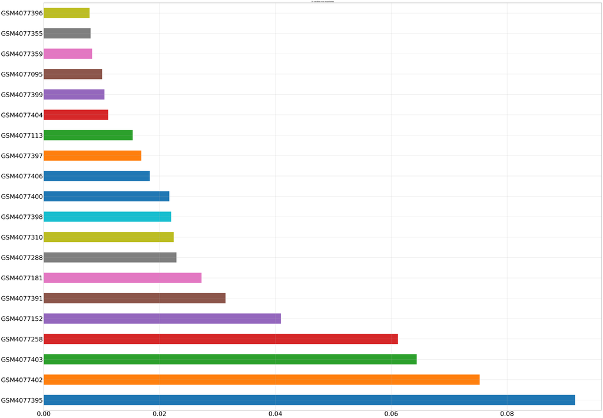

```python
#  almacenamos la importancia de cada variable
importances = rf.feature_importances_

#  almacenamos los indices de las variables de menos a más importantes
indices = np.argsort(importances)

#  nos quedamos con las 50 variables más importantes
top_50_indices = np.sort(np.flip(indices[-50:], 0))

#  mostramos las 20 variables más importantes

top_20_importances = pd.Series(importances, index=labels)
top_20_importances.nlargest(20).plot(kind='barh', title='20 variables más importantes',
                                     fontsize= 50, figsize=(80, 60), grid= True)
```

```python
#  nuevo conjunto de datos seleccionando solo las 50 variables más importantes
new_X = X[:, top_50_indices]
new_X = new_X.round(decimals=3)

new_x_train, new_x_test, new_y_train, new_y_test = train_test_split(new_X, Y, test_size = 0.8, random_state = 42)

#  entrenamos el nuevo modelo y vemos cómo se comporta
rf2 = RandomForestRegressor(n_estimators = 1000,
                           n_jobs = -1,
                           oob_score = True,
                           bootstrap = True,
                           random_state = 42)

rf2.fit(new_x_train, new_y_train)

print('R^2 Training Score: {:.2f} \nOOB Score: {:.2f} \nR^2 Validation Score: {:.2f}'.format(rf2.score(new_x_train, new_y_train),
                                                                                             rf2.oob_score_,
                                                                                             rf2.score(new_x_test, new_y_test)))
```

```
R^2 Training Score: 0.98
OOB Score: 0.82
R^2 Validation Score: 0.81
```

Observamos que el nuevo modelo se comporta prácticamente igual que el anterior, por lo que podemos concluir que seleccionando únicamente estas 50 variables para el nuevo dataset no vamos a perder demasiada información. El último paso será guardar el nuevo dataset para poder utilizarlo en el análisis GSEA

```python
new_dataset = pd.DataFrame(new_X, columns=[labels[i] for i in (top_50_indices)])
new_dataset.insert(0, "NAME", sondas, True)

new_dataset.head(10)
```

|  | NAME | GSM4077040 | GSM4077042 | GSM4077044 | GSM4077075 | GSM4077095 | GSM4077113 | GSM4077124 | GSM4077135 | GSM4077136 | ... | GSM4077397 | GSM4077398 | GSM4077399 | GSM4077400 | GSM4077401 | GSM4077402 | GSM4077403 | GSM4077404 | GSM4077405 | GSM4077406 |
| --- | --- | --- | --- | --- | --- | --- | --- | --- | --- | --- | --- | --- | --- | --- | --- | --- | --- | --- | --- | --- | --- |
| 0 | ADXECRS.38499_at | 29.979 | 26.826 | 23.879 | 29.703 | 28.679 | 3.215 | 28.895 | 28.115 | 27.746 | ... | 29.614 | 29.056 | 28.409 | 29.101 | 27.757 | 27.126 | 29.526 | 29.428 | 30.205 | 29.756 |
| 1 | ADXEC.16333.C1_s_at | 31.906 | 34.472 | 35.896 | 27.556 | 29.616 | 28.449 | 39.446 | 31.597 | 23.767 | ... | 46.058 | 41.706 | 44.892 | 39.685 | 44.456 | 42.478 | 41.928 | 36.600 | 38.545 | 41.558 |
| 2 | ADXEC.26151.C1_at | 37.064 | 36.435 | 24.117 | 36.073 | 33.492 | 36.012 | 38.318 | 41.825 | 40.060 | ... | 45.680 | 32.336 | 38.878 | 46.378 | 45.090 | 47.629 | 47.056 | 31.562 | 36.811 | 47.068 |
| 3 | ADXEC.12634.C1_at | 58.435 | 77.093 | 69.489 | 71.059 | 76.052 | 69.632 | 72.713 | 61.728 | 69.269 | ... | 72.903 | 70.616 | 74.074 | 70.728 | 72.878 | 6.680 | 74.982 | 74.293 | 72.864 | 69.651 |
| 4 | ADXEC.11494.C1-a_s_at | 31.052 | 33.416 | 36.067 | 30.759 | 29.062 | 28.763 | 33.561 | 31.516 | 23.313 | ... | 43.740 | 50.086 | 65.113 | 45.085 | 66.724 | 45.366 | 65.342 | 66.582 | 42.440 | 41.247 |
| 5 | ADXEC.14889.C1_at | 30.614 | 38.266 | 43.343 | 48.313 | 30.986 | 41.184 | 46.308 | 34.989 | 34.064 | ... | 77.351 | 77.149 | 55.927 | 69.029 | 75.808 | 67.635 | 64.132 | 74.062 | 76.284 | 68.761 |
| 6 | 200015_s_at | 34.978 | 57.079 | 44.331 | 56.787 | 42.095 | 49.838 | 56.616 | 46.745 | 47.634 | ... | 81.254 | 78.587 | 74.266 | 80.751 | 71.466 | 81.115 | 76.019 | 71.404 | 70.058 | 74.510 |
| 7 | ADXEC.14526.C1-a_s_at | 30.153 | 44.045 | 23.466 | 28.176 | 27.258 | 46.572 | 35.458 | 28.849 | 20.649 | ... | 39.623 | 21.736 | 45.911 | 42.391 | 31.347 | 40.026 | 39.674 | 38.222 | 42.497 | 35.973 |
| 8 | ADXEC.18832.C1-a_s_at | 47.506 | 38.783 | 41.825 | 40.415 | 31.295 | 40.548 | 36.420 | 32.484 | 35.292 | ... | 58.920 | 64.037 | 58.825 | 53.384 | 65.063 | 64.333 | 63.000 | 53.637 | 61.321 | 62.073 |
| 9 | ADXEC.21749.C1_at | 37.631 | 40.218 | 37.059 | 35.918 | 35.824 | 31.897 | 36.753 | 37.959 | 34.282 | ... | 9.082 | 90.673 | 89.243 | 93.368 | 93.072 | 91.779 | 90.417 | 89.384 | 89.699 | 90.811 |

10 rows × 51 columns

Por último almacenamos el dataset en formato csv

```python
export_csv = new_dataset.to_csv (r'C:\Users\alfon\Dropbox\Master Data Science\Asignaturas\TFM\PEC3\new_dataset.csv', index=None, header=True)
```